# Final_RDAVIS_SidneyWoodruff_updated

##### Question 4)

*Make a combination violin/scatterplot showing departure delay by manufacturer, and add a facet for whether or not it’s raining. Hint: you’ll have to make a new column to classify “raining” or “not raining”, the exact method is up to you.*

**View code here!**

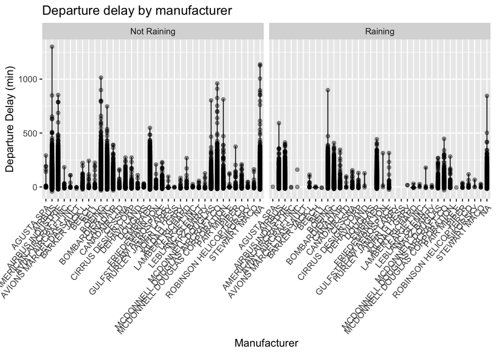

```r
# Making column with raining or not raining
fpw$rain <- ifelse(fpw$precip >0, "Raining", "Not Raining")


q4 <- fpw %>%
  filter(!is.na(dep_delay)) %>%
  filter(rain == "Raining" | rain == "Not Raining") %>%
  ggplot(mapping = aes(x = manufacturer, y = dep_delay)) +
  geom_violin() +
  geom_point(alpha = 0.4) +
  theme(axis.text.x = element_text(angle = 50, hjust = 1)) +
  facet_wrap(~rain) +
  labs(x = "Manufacturer", y = "Departure Delay (min)", title = "Departure delay by manufacturer")
```

##### Question 5)

*Insert an image of the coolest plane in the planes dataset (the choice is yours). Add a link to a webpage with some information on this super cool plane. Bonus points if your image is a GIF (not really bonus points but we’ll like it).*

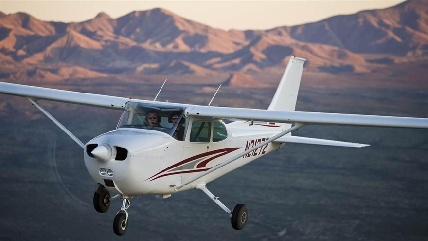

1974 Cessna 172M

[Link to some information about getting this plane!](https://planephd.com/wizard/details/189/CESSNA-172M-Skyhawk-specifications-performance-operating-cost-valuation)